# Data Mining for the Social Sciences - Capstone Project

Alluri Vishal

2024-05-31

## 1) Introduction

Media plays a key role in shaping public opinion and political outcomes. In the context of elections, the frequency and focus of media coverage on certain topics increases the salience of these issues among public and influences their vote behavior. This project aims to visualize the interplay between media coverage of the top “worries” of Swiss citizens and the outcomes of Swiss Federal elections 2023.

In this project, two main aspects are visualized using a shiny app:

Salience of Worries in Media: Examining the frequency of topics (top concerns of swiss citizens) in media articles to gain insights into the issues being focused on in the public discourse.

Voting Results of Swiss Federal Elections: Map the voting results, focusing on the strength of the winning party of each canton in the 2023 Federal Election.

This might give a clearer idea of which issues were highly discussed leading to the election and whether the goals of the majority party align with these prominently covered issues.

## 2) Data Sources

1. Media Coverage Data: TheNewsAPI was utilized to gather media articles and related data from swiss sources. (thenewsapi.com)
2. Electoral Data: Voting results of the Swiss Federal elections were obtained from the open data platform, opendata.swiss
3. Geographical Data: the shapefiles for canton boundaries, were sourced from Swisstopo—the Federal Office of Topography of Switzerland.  
   (https://www.swisstopo.admin.ch/de/landschaftsmodell-swissboundaries3d)

## 3) Data Operationalization

### 3.1) Operationalization steps of Media Queries:

1. The Credit Suisse Worry Barometer is used as a key reference. It provides statistics on the main concerns of Swiss citizens (such as healthcare, immigration, environment etc). (https://www.credit-suisse.com/sustainability/en/thought-leadership/worry-barometer.html)
2. For each major topic identified by the Worry Barometer, specific search terms were created,to search for articles from TheNewsAPI. The focus was on articles published within the three months leading up to the election day - to capture the most relevant and recent media coverage that could influence or reflect voters’ preferences.

```r
search_terms <- list(
  health = '"healthcare" | "health insurance"',
  environment = '"environment" + "protection" | "climate change"',
  retirement = '"AHV" | "retirement" + "provision"',
  eu_relations = 'EU',
  energy = '"Energy" + "issues"',
  immigration = '"Foreigners" | "Immigration"',
  inflation = '"Inflation"',
  housing = '"housing + costs" | "rent"',
  refugees = '"Refugees"',
  social_security = '"Social" + "security"'
)
```

3. The only Swiss news source used was swissinfo.ch (English articles). Other popular sources were ignored as they publish articles in German, French, or Italian, which I do not speak, making it difficult to create appropriate search terms in those languages.

## 4) Exploratory Data Analysis

### 4.1) Salience of topics

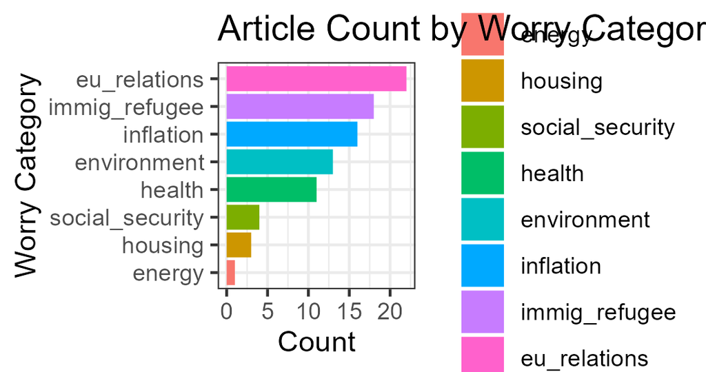

```r
knitr::include_graphics(path = "plots/most_covered_worry.png")
```

The above plot was generated by assigning each article to the ‘worry’ category they belong to. - EU relations and immigration/refugee concerns dominated the media landscape in the last three months leading to the election day, suggesting these were critical concerns of both the media and, potentially, the voting public. - Energy and housing received the least attention during this period.

### 4.2) Trends of worry category frequency over the 3 month period

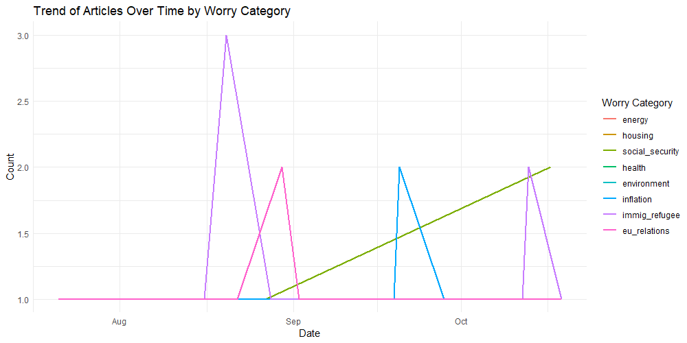

```r
knitr::include_graphics(path = "plots/article_trends.png")
```

Social security concerns saw a steady rise in reporting from September to end of October. Immigration concerns were highly reported initially, dropped in frequency and again received high attention close to the election day. EU relations were steadily reported during the entire period.

The above plot is imperfect as it only accounts for articles from one media source, but with more data (from other media sources and also considering a wider time frame) the trends can paint a better picture.

### 4.3) Election results 2023

```r
knitr::include_graphics(path = "plots/map.png")
```

[figure not shown]

This displays: which party has the majority share in each canton? and its strength (measured by percentage of votes). The visualization was created by merging the shape file data and selected election results data.

The strong support for majority parties in certain regions indicates political homogeneity. This might be due to local economic factors, historical political affiliations, or regional issues. On the other hand, areas with lower support for the leading party likely have more political diversity and competition.

The key takeaway is SVP has a majority across Switzerland.

## 5) Closing Discussion

### 5.1) SHINY app results

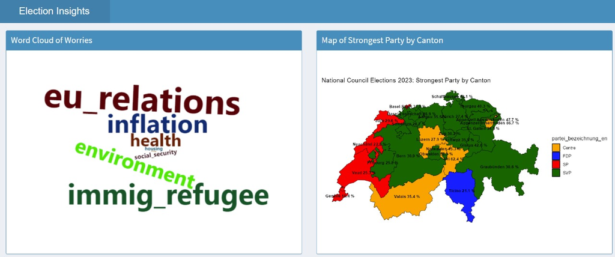

```r
knitr::include_graphics(path = "plots/app_worries_partystrength.jpg")
```

The word cloud visualization from the Shiny app shows that “EU relations” and “immigration/refugee” were the most discussed topics by ‘swissinfo.ch’ in the three months leading up to the Swiss Federal elections.

The Swiss People’s Party (SVP) won the overall majority in the elections. Notably, the SVP’s main campaign revolved around EU relations and immigration/refugee issues. The salience of these topics in the media likely played a role in boosting SVP’s campaign.

Overall, this project shows that political parties should monitor media trends and tailor their campaigns accordingly. Parties can connect better with voters by focusing on the most salient issues, and improve their electoral appeal.

NOTE: These findings are not accurate and only represent the analysis of results within the context of this project. This project only serves as a framework to be built upon.

## 7) Future Implementation

- Enhanced Search Queries: Expanding the set of search terms (by adding more keywords) could help in filtering the data more effectively.
- Multilingual Support: Including german, french, and italian search terms is necessary. This would allow to capture media outputs from all major news outlets across the country, meaning a more comprehensive view of the media landscape.
- Historical Data Comparison: Collecting and including data from previous elections would be valuable. We could better understand how media influence and public concerns have evolved over time. This could be integrated into the Shiny app to allow users to compare how different issues and party strengths have shifted from one election cycle to the next.
- Color coding ‘worries’ based on the party ideology would make it visually easier to compare the relationship between the media salience of a topic and the majority party ideology.